# 로지스틱 보완

## 데이터 전처리

```python
import pandas as pd

dat = pd.read_csv('netflix_original_종합_수정(sum)_(정량화보함)2.csv') # 데이터 불러오기
```

```python
dat.info()
```

```
<class 'pandas.core.frame.DataFrame'>
RangeIndex: 589 entries, 0 to 588
Data columns (total 82 columns):
 #   Column                     Non-Null Count  Dtype
---  ------                     --------------  -----
 0   Unnamed: 0                 589 non-null    int64
 1   Title                      589 non-null    object
 2   Genre                      589 non-null    object
 3   Original Network           589 non-null    object
 4   Premiere                   589 non-null    object
 5   Seasons                    589 non-null    int64
 6   Short_Length               585 non-null    object
 7   Long_Length                585 non-null    object
 8   Mean_Length                589 non-null    float64
 9   Netflix Exclusive Regions  589 non-null    object
```

[output cut: 74 more lines]

```python
dat = dat.drop(['Unnamed: 0', 'Title', 'Genre', 'Original Network', 'Premiere', 'Seasons','Short_Length', 'Long_Length', 'Netflix Exclusive Regions', 'Status', 'Director', 'Director_award', 'Stars', 'All_rating', 'Preview'], axis=1)
```

```python
dat = dat.iloc[:, :26]
```

```python
dat.info()
```

```
<class 'pandas.core.frame.DataFrame'>
RangeIndex: 589 entries, 0 to 588
Data columns (total 26 columns):
 #   Column              Non-Null Count  Dtype
---  ------              --------------  -----
 0   Mean_Length         589 non-null    float64
 1   Ratings             589 non-null    float64
 2   Voters              589 non-null    object
 3   Director_max_award  510 non-null    float64
 4   18_rating           589 non-null    object
 5   18_29_rating        589 non-null    float64
 6   30_44_rating        589 non-null    float64
 7   45_rating           589 non-null    float64
 8   Males_rating        589 non-null    float64
 9   Famales_rating      589 non-null    float64
```

[output cut: 18 more lines]

위에 해당 되는 열만 사용

age, year, harmful_themes 등과 같은 경우 각각의 등급을 한개의 열로 사용할 경우 column이 너무 많아지고, 열 하나하나 마다 0인 값이 너무 많아지게 되어서 특성들의 영향을 제대로 파악할 수 없음  
==> 따라서 분리되어 있는 등급을 하나로 묶어 높음=3, 다소높음=2, 보통=1, 나머지는 0을 부여

```python
dat = dat.dropna(axis=0, how='any').astype(str) # 결측치 포함 행 제거
dat.reset_index(drop=True, inplace=True) # 인덱스 정렬
```

```python
import re

lst = dat.columns.to_list() # 불필요한 문자 제거
for i in lst:
    for j in range(len(dat)):
        dat[i][j] = re.sub("[,-]", '', dat[i][j])
        if dat[i][j] == '':
            dat[i][j] = '0'

dat.head(1)
```

|  | Mean_Length | Ratings | Voters | Director_max_award | 18_rating | 18_29_rating | 30_44_rating | 45_rating | Males_rating | Famales_rating | ... | Famales_voter | Age | Year | Harmful_themes | Lewdness | Violence | Profanity | Fear | Drugs | Immatatable |
| --- | --- | --- | --- | --- | --- | --- | --- | --- | --- | --- | --- | --- | --- | --- | --- | --- | --- | --- | --- | --- | --- |
| 0 | 50.5 | 8.7 | 468505 | 2.0 | 8.4 | 8.8 | 8.7 | 8.5 | 8.7 | 8.7 | ... | 58292 | 청소년관람불가 | 2018.0 | 높음 | 높음 | 높음 | 높음 | 보통 | 높음 | 높음 |

1 rows × 26 columns

```python
pd.unique(dat['Harmful_themes'])
```

```
array(['높음', '다소높음', '.', '보통'], dtype=object)
```

```python
for i in range(19,26): # 범주형 자료를 수치로 변환
    for j in range(len(dat)):
        if dat.iloc[j,i]=='높음':
            dat.iloc[j,i]=3
        elif dat.iloc[j,i]=='다소높음':
            dat.iloc[j,i]=2
        elif dat.iloc[j,i]=='보통':
            dat.iloc[j,i]=1
        else:
            dat.iloc[j,i]=0
```

```python
for i in range(len(dat)): # age도 수치로 변환
    if dat['Age'][i]=='청소년관람불가':
        dat['Age'][i]=3
    elif dat['Age'][i]=='15세이상관람가':
        dat['Age'][i]=2
    else:
        dat['Age'][i]=1
```

```python
dat = dat.apply(pd.to_numeric, errors='coerce')
dat['Year'] = dat['Year'].astype(int)
dat['Director_max_award'] = dat['Director_max_award'].astype(int)
dat.info()
```

```
<class 'pandas.core.frame.DataFrame'>
RangeIndex: 503 entries, 0 to 502
Data columns (total 26 columns):
 #   Column              Non-Null Count  Dtype
---  ------              --------------  -----
 0   Mean_Length         503 non-null    float64
 1   Ratings             503 non-null    float64
 2   Voters              503 non-null    int64
 3   Director_max_award  503 non-null    int32
 4   18_rating           503 non-null    float64
 5   18_29_rating        503 non-null    float64
 6   30_44_rating        503 non-null    float64
 7   45_rating           503 non-null    float64
 8   Males_rating        503 non-null    float64
 9   Famales_rating      503 non-null    float64
```

[output cut: 18 more lines]

로지스틱 회귀분석을 적용하기 위해 str 타입인 특성들을 numeric형으로 변경

```python
dat.describe() # 기초통계량
```

|  | Mean_Length | Ratings | Voters | Director_max_award | 18_rating | 18_29_rating | 30_44_rating | 45_rating | Males_rating | Famales_rating | ... | Famales_voter | Age | Year | Harmful_themes | Lewdness | Violence | Profanity | Fear | Drugs | Immatatable |
| --- | --- | --- | --- | --- | --- | --- | --- | --- | --- | --- | --- | --- | --- | --- | --- | --- | --- | --- | --- | --- | --- |
| count | 503.000000 | 503.000000 | 503.000000 | 503.000000 | 503.000000 | 503.000000 | 503.000000 | 503.000000 | 503.000000 | 503.00000 | ... | 503.000000 | 503.000000 | 503.000000 | 503.000000 | 503.000000 | 503.000000 | 503.000000 | 503.000000 | 503.000000 | 503.000000 |
| mean | 82.433400 | 6.519085 | 23505.143141 | 10.546720 | 5.500596 | 6.581909 | 6.463022 | 6.416899 | 6.429225 | 6.64672 | ... | 3599.868787 | 2.240557 | 2018.232604 | 2.081511 | 1.262425 | 1.282306 | 1.783300 | 0.793241 | 1.330020 | 1.332008 |
| std | 33.492195 | 1.030353 | 52886.535937 | 21.874354 | 2.409952 | 1.081707 | 1.021046 | 0.970549 | 1.032423 | 1.05403 | ... | 8010.352276 | 0.767742 | 1.355074 | 0.931582 | 1.187048 | 1.165501 | 1.061251 | 1.067910 | 1.108835 | 1.218675 |
| min | 0.000000 | 2.500000 | 84.000000 | 0.000000 | 0.000000 | 2.300000 | 2.600000 | 2.900000 | 2.600000 | 2.20000 | ... | 1.000000 | 1.000000 | 2013.000000 | 0.000000 | 0.000000 | 0.000000 | 0.000000 | 0.000000 | 0.000000 | 0.000000 |
| 25% | 54.500000 | 5.900000 | 1973.500000 | 0.000000 | 5.000000 | 5.900000 | 5.800000 | 5.800000 | 5.800000 | 6.00000 | ... | 202.500000 | 2.000000 | 2017.000000 | 2.000000 | 0.000000 | 0.000000 | 1.000000 | 0.000000 | 0.000000 | 0.000000 |
| 50% | 92.000000 | 6.500000 | 5688.000000 | 3.000000 | 6.000000 | 6.600000 | 6.500000 | 6.400000 | 6.400000 | 6.70000 | ... | 871.000000 | 2.000000 | 2018.000000 | 2.000000 | 1.000000 | 1.000000 | 2.000000 | 0.000000 | 1.000000 | 1.000000 |
| 75% | 104.000000 | 7.200000 | 19147.500000 | 10.000000 | 7.000000 | 7.300000 | 7.200000 | 7.100000 | 7.200000 | 7.40000 | ... | 3777.500000 | 3.000000 | 2019.000000 | 3.000000 | 2.000000 | 2.000000 | 3.000000 | 2.000000 | 2.000000 | 2.000000 |
| max | 209.000000 | 8.800000 | 468505.000000 | 203.000000 | 10.000000 | 9.000000 | 8.800000 | 8.600000 | 8.800000 | 8.80000 | ... | 85931.000000 | 3.000000 | 2020.000000 | 3.000000 | 3.000000 | 3.000000 | 3.000000 | 3.000000 | 3.000000 | 3.000000 |

8 rows × 26 columns

data 기초통계량을 확인해 보면 ratings의 Q2가 6.5임을 확인할 수 있고,  
이를 기준으로 성공=1, 실패=0으로 나눔

```python
for i in range(len(dat)):
    if dat['Ratings'][i] >= 6.500000:
        dat['Ratings'][i]=1
    else:
        dat['Ratings'][i]=0
```

```python
dat.head(1)
```

|  | Mean_Length | Ratings | Voters | Director_max_award | 18_rating | 18_29_rating | 30_44_rating | 45_rating | Males_rating | Famales_rating | ... | Famales_voter | Age | Year | Harmful_themes | Lewdness | Violence | Profanity | Fear | Drugs | Immatatable |
| --- | --- | --- | --- | --- | --- | --- | --- | --- | --- | --- | --- | --- | --- | --- | --- | --- | --- | --- | --- | --- | --- |
| 0 | 50.5 | 1.0 | 468505 | 2 | 8.4 | 8.8 | 8.7 | 8.5 | 8.7 | 8.7 | ... | 58292 | 3 | 2018 | 3 | 3 | 3 | 3 | 1 | 3 | 3 |

1 rows × 26 columns

## 모델링

### training set, test set 분리

```python
from sklearn.model_selection import train_test_split

x = dat.drop(['Ratings'], axis=1)
y = dat.loc[:, 'Ratings']

x_train, x_test, y_train, y_test = train_test_split(x, y)
```

종속변수=Ratings, 나머지를 설명변수로 하여 모델링

### 표준화

```python
from sklearn.preprocessing import StandardScaler

ss = StandardScaler()
ss.fit(x_train)
x_train_ss = ss.transform(x_train)
x_test_ss = ss.transform(x_test)
```

### LogisticRegression + GridSearch

로지스틱 회귀분석와 그리드 서치를 함께 적용하여 최적인 하이퍼 파라미터 확인

```python
from sklearn.linear_model import LogisticRegression
from sklearn.model_selection import GridSearchCV

lr = LogisticRegression()
param_grid = {'C': [0.001, 0.01, 0.1, 1, 10, 100, 1000], 'penalty': ['l2', 'l1'], 'solver': ['newton-cg', 'lbfgs', 'liblinear', 'sag', 'saga']}
gs = GridSearchCV(estimator=lr, param_grid = param_grid, cv=5, n_jobs=-1)
gs.fit(x_train_ss, y_train)
print('best params: {}'.format(gs.best_params_))
```

```
best params: {'C': 0.1, 'penalty': 'l1', 'solver': 'saga'}
```

```python
lr2 = gs.fit(x_train_ss, y_train)
print('train score: {}'.format(lr2.score(x_train_ss, y_train)))
print('test score: {}'.format(lr2.score(x_test_ss, y_test)))
```

```
train score: 0.9814323607427056
test score: 0.9761904761904762
```

'C': 0.1, 'penalty': 'l1', 'solver': 'saga' 가 하이퍼 파라미터로 선택되었고,  
train과 test의 score를 확인해 보면 과대적합, 과소적합 없이 적합이 잘 되었음을 확인 가능

```python
# GridSearchCV가 coef_ 지원 x => best_params_를 다시 lr에 적합
lr3 = LogisticRegression(C=0.1, penalty='l1', solver='saga')
lr3.fit(x_train_ss, y_train)
print(lr3.coef_, lr3.intercept_)
```

```
[[0.         0.         0.         0.         0.94491534 1.26229382
  0.38921266 1.12979282 0.65760132 0.         0.         0.
  0.         0.         0.         0.         0.         0.
  0.         0.         0.         0.         0.         0.
  0.        ]] [0.4546573]
```

## 평가 지표

### confusion matrix

예측 결과에서 어떤 오류를 발생하고 있는지 나타내는 지표  
1사분면: FP(False Positive)  
2사분면: TN(True Negative)  
3사분면: FN(Fasle Negative)  
4사분면: TP(True Positive)

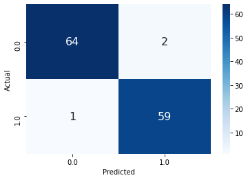

```python
import numpy as np
import matplotlib.pyplot as plt
import seaborn as sns
from sklearn.metrics import accuracy_score, f1_score, recall_score, precision_score, classification_report, confusion_matrix

pred_test = lr2.predict(x_test_ss) # 예측값

conf_mx = confusion_matrix(y_test, pred_test)

heat_cm = pd.DataFrame(conf_mx, columns=np.unique(y_test), index = np.unique(y_test))
heat_cm.index.name = 'Actual'
heat_cm.columns.name = 'Predicted'

sns.heatmap(heat_cm, cmap="Blues", annot=True, annot_kws={"size": 16})
```

정확히 예측한 값은 TN과 TP로, 1사분면과 3사분면의 값이 가능한 적어야 좋은 모델임.  
==> 적합한 모델이 타당함을 확인할 수 있음.

### Precision, Recall, F1-Score

Precision = TP / ( FP + TP )  
예측을 positive로 한 대상 중 예측과 실제 값이 positive로 일치하는 비율

Recall = TP / ( TP + FN )  
실제값이 positive인 대상 중에 예측과 실제 값이 positive로 일치하는 데이터의 비율

```python
print(classification_report(y_test, pred_test))
```

```
              precision    recall  f1-score   support

         0.0       0.98      0.97      0.98        66
         1.0       0.97      0.98      0.98        60

    accuracy                           0.98       126
   macro avg       0.98      0.98      0.98       126
weighted avg       0.98      0.98      0.98       126
```

precision, recall, f1-score 모두 높은 값으로 모델이 타당함.

### ROC, AUC

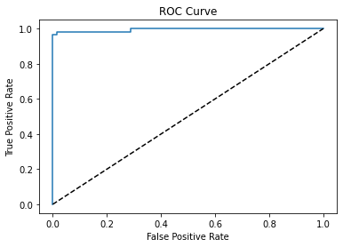

```python
from sklearn.metrics import roc_curve, auc

y_test_pred_probs = lr2.predict_proba(x_test)[:,1]

FPR, TPR, _ = roc_curve(y_test, y_test_pred_probs)

plt.plot(FPR, TPR)
plt.plot([0,1],[0,1],'--', color='black') # 대각선
plt.title('ROC Curve')
plt.xlabel('False Positive Rate')
plt.ylabel('True Positive Rate')
plt.show()
plt.clf()
```

## 성공, 실패 집단 특성별 평균 비교

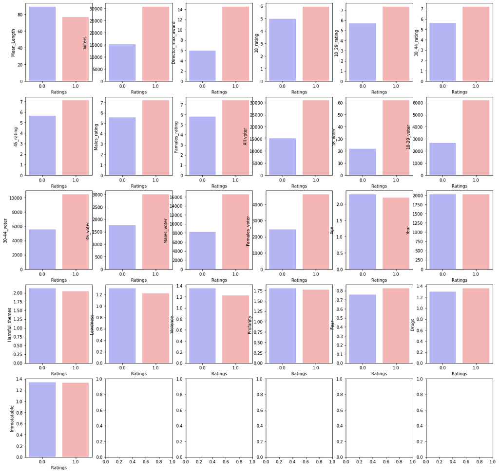

|  | Ratings | Mean_Length | Voters | Director_max_award | 18_rating | 18_29_rating | 30_44_rating | 45_rating | Males_rating | Famales_rating | ... | Famales_voter | Age | Year | Harmful_themes | Lewdness | Violence | Profanity | Fear | Drugs | Immatatable |
| --- | --- | --- | --- | --- | --- | --- | --- | --- | --- | --- | --- | --- | --- | --- | --- | --- | --- | --- | --- | --- | --- |
| 0 | 0.0 | 89.308511 | 15212.182979 | 5.987234 | 4.975745 | 5.690213 | 5.608936 | 5.632340 | 5.570213 | 5.792340 | ... | 2445.191489 | 2.289362 | 2018.378723 | 2.123404 | 1.306383 | 1.348936 | 1.800000 | 0.757447 | 1.297872 | 1.336170 |
| 1 | 1.0 | 76.404851 | 30776.955224 | 14.544776 | 5.960821 | 7.363806 | 7.211940 | 7.104851 | 7.182463 | 7.395896 | ... | 4612.365672 | 2.197761 | 2018.104478 | 2.044776 | 1.223881 | 1.223881 | 1.768657 | 0.824627 | 1.358209 | 1.328358 |

2 rows × 26 columns

```python
import matplotlib.pyplot as plt
import seaborn as sns

central = dat.groupby('Ratings').mean().reset_index()
features = list(central.keys()[1:])

fig, ax = plt.subplots(5, 6, figsize=(20,20))

ax = ax.ravel()
position = 0

for i in features:
  sns.barplot(data=central, x='Ratings', y=i, ax=ax[position], palette='bwr')
  position += 1

plt.show()
display(central)
```